# Day 2: Data Manipulation and Simple Visualization in R

Kumar Ramanathan (based on materials by Christina Maimone)

2020-08-17

# Data manipulation in base R

## Exploring a data frame

In the previous section, we imported two datasets. For the rest of today, we will focus on the Gapminder data, which is stored in our environment as `gapminder`. To refresh yourself, you can view the data frame in R using the `View()` function.

```r
library(readr)
gapminder <- read_csv("data/gapminder5.csv")
View(gapminder)
```

You can also see a list of variables using `names()`.

```r
names(gapminder)
```

```
## [1] "country"   "year"      "pop"       "continent" "lifeExp"   "gdpPercap"
```

When applied to a data frame, the `summary()` function provides useful summary statistics for each variable (i.e. column) in the data frame. Let’s try it with the Gapminder data:

```r
summary(gapminder)
```

```
##    country               year           pop             continent
##  Length:1704        Min.   :1952   Min.   :6.001e+04   Length:1704
##  Class :character   1st Qu.:1966   1st Qu.:2.794e+06   Class :character
##  Mode  :character   Median :1980   Median :7.024e+06   Mode  :character
##                     Mean   :1980   Mean   :2.960e+07
##                     3rd Qu.:1993   3rd Qu.:1.959e+07
##                     Max.   :2007   Max.   :1.319e+09
##     lifeExp        gdpPercap
##  Min.   :23.60   Min.   :   241.2
##  1st Qu.:48.20   1st Qu.:  1202.1
##  Median :60.71   Median :  3531.8
##  Mean   :59.47   Mean   :  7215.3
##  3rd Qu.:70.85   3rd Qu.:  9325.5
##  Max.   :82.60   Max.   :113523.1
```

We can also use functions like `mean()`, `median()`, `var()`, `sd()`, and `quantile()` to calculate other summary statistics for individual variables. For example, let’s calculate the mean of life expectancy. Recall that we can use the `$` operator to call up a variable within a data frame using its name.

```r
mean(gapminder$lifeExp)
```

```
## [1] 59.47444
```

A useful way to examine a discrete or categorical variable is to use a frequency table. These are easy to make in R, using the `table()` function:

```r
table(gapminder$continent)
```

```
##
##   Africa Americas     Asia   Europe  Oceania
##      624      300      396      360       24
```

`prop.table()` is a useful wrapper around `table()`, showing the proportion of rows in each category:

```r
prop.table(table(gapminder$continent))
```

```
##
##     Africa   Americas       Asia     Europe    Oceania
## 0.36619718 0.17605634 0.23239437 0.21126761 0.01408451
```

You can generate a frequency table with more than one variable as well:

```r
table(gapminder$continent, gapminder$year)
```

```
##
##            1952 1957 1962 1967 1972 1977 1982 1987 1992 1997 2002 2007
##   Africa     52   52   52   52   52   52   52   52   52   52   52   52
##   Americas   25   25   25   25   25   25   25   25   25   25   25   25
##   Asia       33   33   33   33   33   33   33   33   33   33   33   33
##   Europe     30   30   30   30   30   30   30   30   30   30   30   30
##   Oceania     2    2    2    2    2    2    2    2    2    2    2    2
```

## Subsetting

Notice that each row in the data frame represents one country in a given year. Perhaps we are interested in analyzing only data from one year. To do this, we will have to “subset” our data frame to include only those rows that we want to keep.

The `subset()` function lets you select rows and columns you want to keep. You can either name columns or rows, or include a logical statement such that only rows/columns where the statement is true are retained.

```r
subset(data.frame,
       subset=condition indicating rows to keep,
       select=condition indicating columns to keep)
```

For eaxmple, let’s create a new data frame containing only 2007 data by subsetting the original data frame.

```r
gapminder07 <- subset(gapminder, subset = year==2007)
```

Look at the number of rows in the new data frame: it is only 142, whereas the original data frame has 1704 rows.

```r
nrow(gapminder07)
```

```
## [1] 142
```

## Sorting

The `sort()` function reorders elements, in ascending order by default. You can flip the order by using the `decreasing = TRUE` argument.

```r
sort(gapminder07$lifeExp)
```

```
##   [1] 39.613 42.082 42.384 42.568 42.592 42.731 43.487 43.828 44.741 45.678
##  [11] 46.242 46.388 46.462 46.859 48.159 48.303 48.328 49.339 49.580 50.430
##  [21] 50.651 50.728 51.542 51.579 52.295 52.517 52.906 52.947 54.110 54.467
##  [31] 54.791 55.322 56.007 56.728 56.735 56.867 58.040 58.420 58.556 59.443
##  [41] 59.448 59.545 59.723 60.022 60.916 62.069 62.698 63.062 63.785 64.062
##  [51] 64.164 64.698 65.152 65.483 65.528 65.554 66.803 67.297 69.819 70.198
##  [61] 70.259 70.616 70.650 70.964 71.164 71.338 71.421 71.688 71.752 71.777
##  [71] 71.878 71.993 72.235 72.301 72.390 72.396 72.476 72.535 72.567 72.777
##  [81] 72.801 72.889 72.899 72.961 73.005 73.338 73.422 73.747 73.923 73.952
##  [91] 74.002 74.143 74.241 74.249 74.543 74.663 74.852 74.994 75.320 75.537
## [101] 75.563 75.635 75.640 75.748 76.195 76.384 76.423 76.442 76.486 77.588
## [111] 77.926 78.098 78.242 78.273 78.332 78.400 78.553 78.623 78.746 78.782
## [121] 78.885 79.313 79.406 79.425 79.441 79.483 79.762 79.829 79.972 80.196
## [131] 80.204 80.546 80.653 80.657 80.745 80.884 80.941 81.235 81.701 81.757
## [141] 82.208 82.603
```

```r
sort(gapminder07$lifeExp, decreasing=TRUE)
```

```
##   [1] 82.603 82.208 81.757 81.701 81.235 80.941 80.884 80.745 80.657 80.653
##  [11] 80.546 80.204 80.196 79.972 79.829 79.762 79.483 79.441 79.425 79.406
##  [21] 79.313 78.885 78.782 78.746 78.623 78.553 78.400 78.332 78.273 78.242
##  [31] 78.098 77.926 77.588 76.486 76.442 76.423 76.384 76.195 75.748 75.640
##  [41] 75.635 75.563 75.537 75.320 74.994 74.852 74.663 74.543 74.249 74.241
##  [51] 74.143 74.002 73.952 73.923 73.747 73.422 73.338 73.005 72.961 72.899
##  [61] 72.889 72.801 72.777 72.567 72.535 72.476 72.396 72.390 72.301 72.235
##  [71] 71.993 71.878 71.777 71.752 71.688 71.421 71.338 71.164 70.964 70.650
##  [81] 70.616 70.259 70.198 69.819 67.297 66.803 65.554 65.528 65.483 65.152
##  [91] 64.698 64.164 64.062 63.785 63.062 62.698 62.069 60.916 60.022 59.723
## [101] 59.545 59.448 59.443 58.556 58.420 58.040 56.867 56.735 56.728 56.007
## [111] 55.322 54.791 54.467 54.110 52.947 52.906 52.517 52.295 51.579 51.542
## [121] 50.728 50.651 50.430 49.580 49.339 48.328 48.303 48.159 46.859 46.462
## [131] 46.388 46.242 45.678 44.741 43.828 43.487 42.731 42.592 42.568 42.384
## [141] 42.082 39.613
```

The `order()` function gives you the index positions in sorted order:

```r
order(gapminder07$lifeExp)
```

```
##   [1] 122  87 141 113  74   4 142   1  22  75 108  53  28  95 117  78  31 118
##  [19]  18  20  23  14 133  41  17 127  89  43  69  80  36  29  52  11  46  94
##  [37]  42 129 121  77  47  62  19  49  54  88 140 111  90   9  81  59  27  98
##  [55] 109  12  84  70 130  55  51 128  60  61  86  39 101 102 100 132  40  73
##  [73]  37   3  15 120 107  68  66 110  82  26  93  25  16  57 139 137 131  76
##  [91] 112 125  79 138  85 115  13  38   5  99 103   8  97  32  83 136   2 106
## [109]  34  72 116 104 135  33  35 126  24  71 105  30  63  44  48 134  10  50
## [127]  91   7 114  96  92  65  21  45  64 123 119   6 124  58  56  67
```

```r
head(gapminder07[order(gapminder07$lifeExp, decreasing=TRUE),])
```

```
## # A tibble: 6 x 6
##   country          year       pop continent lifeExp gdpPercap
##   <chr>           <dbl>     <dbl> <chr>       <dbl>     <dbl>
## 1 Japan            2007 127467972 Asia         82.6    31656.
## 2 Hong Kong China  2007   6980412 Asia         82.2    39725.
## 3 Iceland          2007    301931 Europe       81.8    36181.
## 4 Switzerland      2007   7554661 Europe       81.7    37506.
## 5 Australia        2007  20434176 Oceania      81.2    34435.
## 6 Spain            2007  40448191 Europe       80.9    28821.
```

Sorting a table is often useful. For example:

```r
sort(table(gapminder07$continent))
```

```
##
##  Oceania Americas   Europe     Asia   Africa
##        2       25       30       33       52
```

## Adding and removing columns

You can add variables to a data frame in several ways. Here, we will show two standard methods using base R. On Day 3, you will learn about alternatives using the `data.table` and `dplyr` approaches.

To demonstrate, let’s first create a vector with the same number of values as the number of rows in the data frame. If you want to learn what is going on in this code, look at the help file for the function `sample()`.

```r
newvar <- sample(1:5000, 1704, replace = FALSE)
```

You can add a variable/column by using the `cbind()` function:

```r
gapminder <- cbind(gapminder, newvar)
```

You can add a variable/column by assigning it to data frame directly:

```r
gapminder$newvar <- newvar
```

To remove a variable/column from a data frame, you can assign a `NULL` value to the variable:

```r
gapminder$newvar <- NULL
```

You can also remove a variable/column by negatively indexing the data frame:

```r
gapminder <- gapminder[-"newvar"]
gapminder <- gapminder[,-c("newvar")]
# The second method is equivalent to the first, but can be used to remove multiple columns at the same time.
```

To add rows, you can use the function `rbind()`. Remember that rows may include different data types, in which case you would need to use the function `list()`.

## Recoding variables

To recode a variable, you could make a new column, or overwrite the existing one entirely. For example, let’s create a new variable for life expectancy containing rounded values, using the `round()` function.

```r
gapminder07$lifeExp_rounded <- round(gapminder07$lifeExp)
```

If you just want to replace part of a column (or vector), you can assign to a subset. For example, let’s say we want to create a new variable that marks all cases where life expectancy is higher than the mean as “High” and those where it is lower than the mean as “Low”.

```r
# Start by creating a new variable with all missing values
gapminder07$lifeExp_highlow <- NA
# Replace higher-than-mean values with "High"
gapminder07$lifeExp_highlow[gapminder07$lifeExp>mean(gapminder07$lifeExp)] <- "High"
# Replace lower-than-mean values with "Low"
gapminder07$lifeExp_highlow[gapminder07$lifeExp<mean(gapminder07$lifeExp)] <- "Low"
```

There’s also a `recode()` function in the `dplyr` library. You specify the reassignment of values. For example, let’s create a new variable with abbreviated continent names.

```r
library(dplyr)
gapminder07$continent_abrv <- recode(gapminder07$continent,
                                     `Africa`="AF",
                                     `Americas`="AM",
                                     `Asia`="AS",
                                     `Europe`="EU",
                                     `Oceania`="OC")
table(gapminder07$continent_abrv)
```

```
##
## AF AM AS EU OC
## 52 25 33 30  2
```

## Aggregating

To compute summary statistics by groups in the data, one option is to use the `aggregate()` function. For example, we can calculate the mean of life expectancy for each continent:

```r
aggregate(gapminder07$lifeExp ~ gapminder07$continent, FUN=mean)
```

```
##   gapminder07$continent gapminder07$lifeExp
## 1                Africa            54.80604
## 2              Americas            73.60812
## 3                  Asia            70.72848
## 4                Europe            77.64860
## 5               Oceania            80.71950
```

The `~` operator can be read as “by” or “as a function of”, and is used in many contexts. A construction such as `y ~ x1 + x2` is referred to as a *formula*.

We can also aggregate by two variables. For example, let’s use the original Gapminder data (not just the 2007 data) and aggregate by continent *and* year.

```r
aggregate(gapminder$lifeExp ~ gapminder$year + gapminder$continent, FUN=mean)
```

```
##    gapminder$year gapminder$continent gapminder$lifeExp
## 1            1952              Africa          39.13550
## 2            1957              Africa          41.26635
## 3            1962              Africa          43.31944
## 4            1967              Africa          45.33454
## 5            1972              Africa          47.45094
## 6            1977              Africa          49.58042
## 7            1982              Africa          51.59287
## 8            1987              Africa          53.34479
## 9            1992              Africa          53.62958
## 10           1997              Africa          53.59827
## 11           2002              Africa          53.32523
## 12           2007              Africa          54.80604
## 13           1952            Americas          53.27984
## 14           1957            Americas          55.96028
```

[output cut: 46 more lines]

## Statistics

Now that we have a dataset … we can do statistics! You will learn more about particular statistical models and methods over the course of your program. For now, let’s do some basic things to get a feel for how R handles statistical analysis.

### Correlations

You can use the `cor()` function to calculate correlation (Pearson’s r):

```r
cor(gapminder07$lifeExp, gapminder07$gdpPercap)
```

```
## [1] 0.6786624
```

You can also find the covariance:

```r
cov(gapminder07$lifeExp, gapminder07$gdpPercap)
```

```
## [1] 105368
```

### T-test

Do countries with high or low life expectancy have different GDP per capita? Apart from simply comparing the means for the two groups, we can use a T-test to evaluate the likelihood that these means are significantly different from each other.

```r
t.test(gapminder07$gdpPercap~gapminder07$lifeExp_highlow)
```

```
##
##  Welch Two Sample t-test
##
## data:  gapminder07$gdpPercap by gapminder07$lifeExp_highlow
## t = 10.564, df = 95.704, p-value < 2.2e-16
## alternative hypothesis: true difference in means is not equal to 0
## 95 percent confidence interval:
##  12674.02 18539.14
## sample estimates:
## mean in group High  mean in group Low
##          17944.685           2338.104
```

Remember: you can read `~` as “as a function of”. So the above code reads “GDP per capita as a function of life expectancy”, meaning grouped by or explained by.

We don’t have to use the formula syntax. We can specify data for two different groups. Let’s see if GDP per capita is different when comparing the Americas and Asia.

```r
t.test(gapminder07$gdpPercap[gapminder07$continent=="Asia"], gapminder07$gdpPercap[gapminder07$continent=="Americas"])
```

```
##
##  Welch Two Sample t-test
##
## data:  gapminder07$gdpPercap[gapminder07$continent == "Asia"] and gapminder07$gdpPercap[gapminder07$continent == "Americas"]
## t = 0.46849, df = 55.535, p-value = 0.6413
## alternative hypothesis: true difference in means is not equal to 0
## 95 percent confidence interval:
##  -4816.823  7756.813
## sample estimates:
## mean of x mean of y
##  12473.03  11003.03
```

By storing the output of the T-test (which is a list) as its own object, we can access different parts of the results.

```r
t1 <- t.test(gapminder07$gdpPercap~gapminder07$lifeExp_highlow)
names(t1)
```

```
##  [1] "statistic"   "parameter"   "p.value"     "conf.int"    "estimate"
##  [6] "null.value"  "stderr"      "alternative" "method"      "data.name"
```

```r
t1$p.value
```

```
## [1] 9.507438e-18
```

### Regression

Of course, the two life expectancy “groups” we used above to conduct a T-test are based on a continuous variable indicating life expectancy. We may be more interested in whether this variable predicts GDP per capita rather than the two “groups” that we created using an arbitrary threshold.

The basic syntax for a liner regression is shown below. Note that instead of repeating `df$variablename` several times, we can indicate the data frame name using the `data =` argument and simply use variable names.

```r
lm(y ~ x1 + x2 + x3, data=df_name)
```

Example:

```r
lm(gdpPercap ~ lifeExp, data=gapminder07)
```

```
##
## Call:
## lm(formula = gdpPercap ~ lifeExp, data = gapminder07)
##
## Coefficients:
## (Intercept)      lifeExp
##    -36759.4        722.9
```

The default output isn’t much. You get a lot more with `summary()`:

```r
r1 <- lm(gdpPercap ~ lifeExp, data=gapminder07)
summary(r1)
```

```
##
## Call:
## lm(formula = gdpPercap ~ lifeExp, data = gapminder07)
##
## Residuals:
##    Min     1Q Median     3Q    Max
## -14473  -7840  -2145   6159  28143
##
## Coefficients:
##              Estimate Std. Error t value Pr(>|t|)
## (Intercept) -36759.42    4501.25  -8.166 1.67e-13 ***
## lifeExp        722.90      66.12  10.933  < 2e-16 ***
## ---
## Signif. codes:  0 '***' 0.001 '**' 0.01 '*' 0.05 '.' 0.1 ' ' 1
##
## Residual standard error: 9479 on 140 degrees of freedom
## Multiple R-squared:  0.4606, Adjusted R-squared:  0.4567
## F-statistic: 119.5 on 1 and 140 DF,  p-value: < 2.2e-16
```

Note that a constant (Intercept) term was added automatically.

Let’s try another regression with two indpendent variables. This time, we will predict life expectancy as a function of GDP per capita and population.

```r
r2 <- lm(lifeExp ~ gdpPercap + pop, data=gapminder07)
summary(r2)
```

```
##
## Call:
## lm(formula = lifeExp ~ gdpPercap + pop, data = gapminder07)
##
## Residuals:
##     Min      1Q  Median      3Q     Max
## -22.496  -6.119   1.899   7.018  13.383
##
## Coefficients:
##              Estimate Std. Error t value Pr(>|t|)
## (Intercept) 5.921e+01  1.040e+00  56.906   <2e-16 ***
## gdpPercap   6.416e-04  5.818e-05  11.029   <2e-16 ***
## pop         7.001e-09  5.068e-09   1.381    0.169
## ---
## Signif. codes:  0 '***' 0.001 '**' 0.01 '*' 0.05 '.' 0.1 ' ' 1
##
## Residual standard error: 8.87 on 139 degrees of freedom
## Multiple R-squared:  0.4679, Adjusted R-squared:  0.4602
## F-statistic: 61.11 on 2 and 139 DF,  p-value: < 2.2e-16
```

# Writing data files

You will often want to save your work in R as well. There are a few different ways to save:

## Writing a data file

We imported the `gapminder` data earlier in CSV format, and manipulated it in several ways: we subsetted the 2007 data and added the variables `lifeExp_rounded`, `lifeExp_highlow`. and `continent_abrv`.

The best method for making your workflow and analysis reproducible is to write any data sets you create to plain text files.

Let’s try to save our subsetted and manipulated `gapminder07` data frame as a CSV. To write a CSV, there are `write.csv` and `write.table` functions, similar to their `read` counterparts. The one trick is that you usually want to NOT write row.names.

```r
write.csv(gapminder07, file="data/gapminder_2007_edited.csv",
          row.names=FALSE)
```

Or using `readr` package’s equivalent:

```r
write_csv(schooldata, "data/gapminder_2007_edited.csv")
```

## Saving R objects

You can use the `save` function to save multiple objects together in a file. The standard file extension to use is `.RData`. Example:

```r
save(schooldata, gapminder,
     file = "workshopobjects.RData")
```

To later load in saved data, use the `load` function:

```r
load("workshopobjects.RData")
```

This can be useful if you’re working with multiple objects and want to be able to pick up your work easily later. But`.RData` files generally aren’t portable to other programs, so think of them only as internal R working files – not the format you want to keep data in long-term. Loading a `.RData` file will overwrite objects with the same name already in the environment.

You can also save all the objects in your environment by using the `save.image()` function, or by clicking the “Save” icon in the Environment pane in RStudio.

# Data visualization in base R

We will spend a lot more time later in the boot camp on data visualization, but today we will briefly introduce some functions for visualization that are included in base R. These functions are useful to quickly visualize data in early phases of analysis, and their syntax is often incorporated into other packages. For more advanced and aesthetically pleasing data visualization, you will want to use the `ggplot2` package, which we will go over in detail on Day 3.

## Histograms

Histograms are a simple and useful way to visualize the distribution of a variable. For example, let’s plot a histogram of life expectancy from the `gapminder07` data frame:

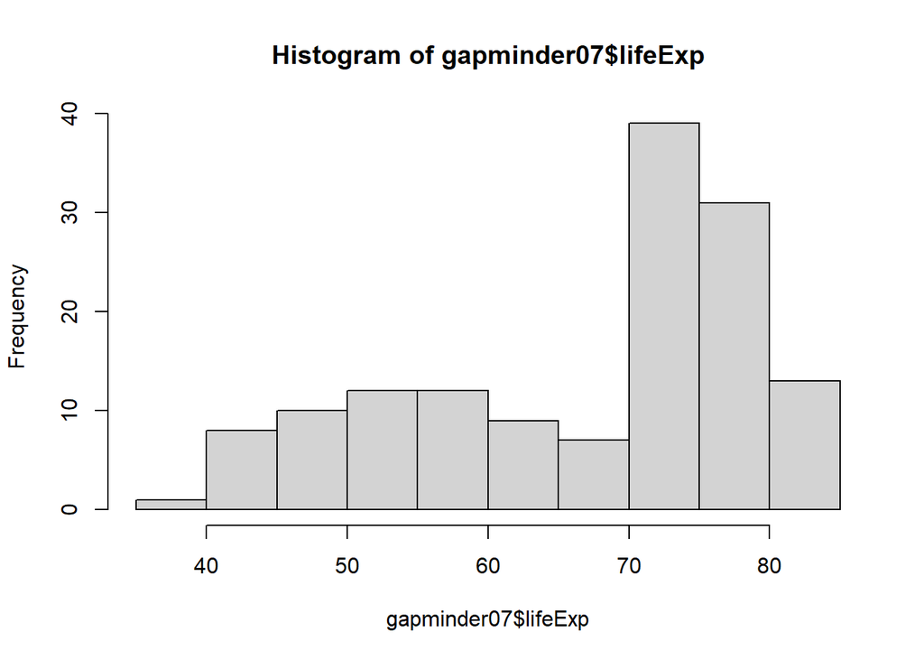

```r
hist(gapminder07$lifeExp)
```

By reading the help file for the `hist()` function, we can identify several arguments that can change the aesthetics of the plot. The `breaks =` argument controls the number of breaks on the x-axis.

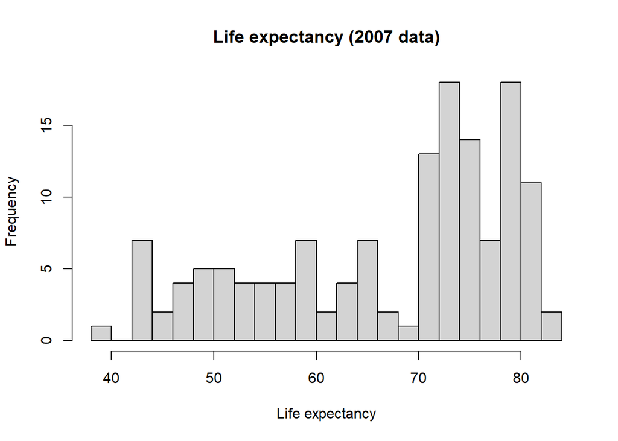

```r
hist(gapminder07$lifeExp, breaks=20,
     main="Life expectancy (2007 data)", ylab="Frequency", xlab="Life expectancy")
```

## Scatterplots

The simplest way to plot the relationship between two variables is a scatterplot. If you provide two variables to the `plot()` function in R, it produces a scatterplot. Let’s try it with life expectancy and GDP per capita in the `gapminder07` data frame. Recall that `~` means “a function of”, so we will put the y-axis variable on the left and the x-axis variable on the right.

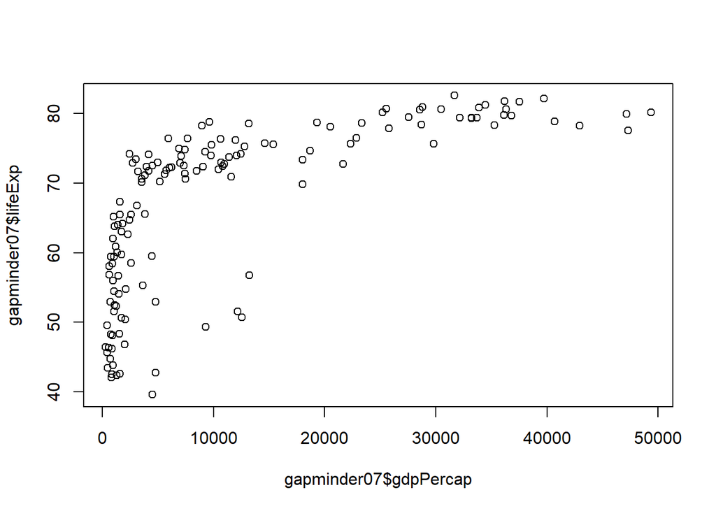

```r
plot(gapminder07$lifeExp ~ gapminder07$gdpPercap)
```

Again, we can add axes and labels:

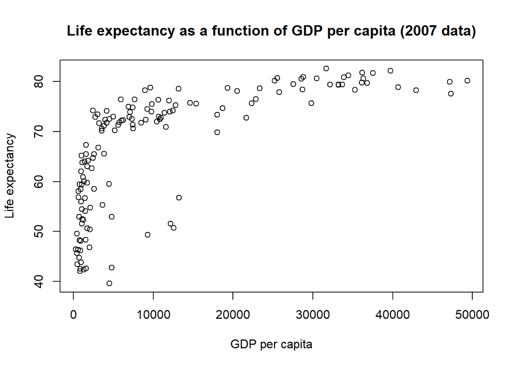

```r
plot(gapminder07$lifeExp ~ gapminder07$gdpPercap, main="Life expectancy as a function of GDP per capita (2007 data)", xlab="GDP per capita", ylab="Life expectancy")
```

Perhaps we want to add a line indicating the mean value of life expectancy. We can do this by using the `abline()` function to add a line after creating a plot. Adding multiple layers to a plot is much more intuitive and flexible with the `ggplot2` package, which we will explore on Day 3.

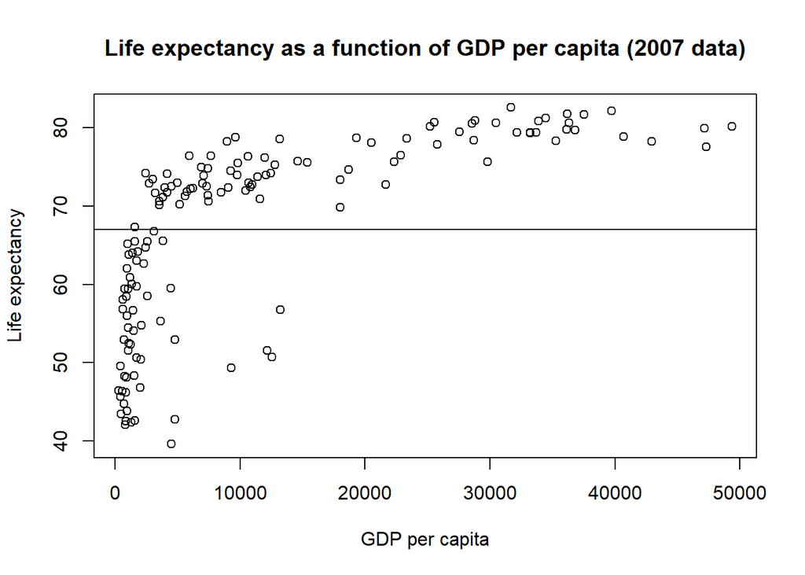

```r
plot(gapminder07$lifeExp ~ gapminder07$gdpPercap, main="Life expectancy as a function of GDP per capita (2007 data)", xlab="GDP per capita", ylab="Life expectancy")
abline(h = mean(gapminder07$lifeExp))
```